# Data Analysis Report with RMarkdown

Yuyan Zhang

2020/8/12

# Demographic Statistics

## Study 1

### Gender

| gender | num_gender |
| --- | --- |
| female | 15 |
| male | 34 |
| nottosay | 1 |

### Age

| mean_age | sd_age | max_age | min_age |
| --- | --- | --- | --- |
| 33.84 | 9.75 | 62 | 20 |

### Education Years

| mean_edu | sd_edu | max_edu | min_edu |
| --- | --- | --- | --- |
| 14.1 | 3.5 | 20 | 2 |

## Study 2

### Gender

| gender | num_gender |
| --- | --- |
| female | 15 |
| male | 35 |

### Age

| mean_age | sd_age | max_age | min_age |
| --- | --- | --- | --- |
| 40.26 | 11.32 | 71 | 23 |

### Education Years

| mean_edu | sd_edu | max_edu | min_edu |
| --- | --- | --- | --- |
| 14.72 | 3.75 | 22 | 4 |

# Model Analysis

## Study 1

### Number of Participants Using Each Model

| conditions | Asocial RL | Random-choice | Unconditional-copying | Copy-the-successful |
| --- | --- | --- | --- | --- |
| 2no | 42 | 8 | NA | NA |
| 4no | 36 | 14 | NA | NA |
| 8no | 33 | 17 | NA | NA |
| 2low | 30 | 10 | 7 | 3 |
| 4low | 22 | 9 | 11 | 8 |
| 8low | 15 | 7 | 15 | 13 |
| 2mid | 27 | 9 | 4 | 10 |
| 4mid | 22 | 8 | 15 | 5 |
| 8mid | 15 | 9 | 19 | 7 |
| 2high | 27 | 5 | 10 | 8 |
| 4high | 21 | 12 | 11 | 6 |
| 8high | 23 | 8 | 14 | 5 |

### Number of Participants Using a Social or an Asocial Strategy

| conditions | asocial | social |
| --- | --- | --- |
| 2no | 50 | NA |
| 4no | 50 | NA |
| 8no | 50 | NA |
| 2low | 40 | 10 |
| 4low | 31 | 19 |
| 8low | 22 | 28 |
| 2mid | 36 | 14 |
| 4mid | 30 | 20 |
| 8mid | 24 | 26 |
| 2high | 32 | 18 |
| 4high | 33 | 17 |
| 8high | 31 | 19 |

There are 7 participants always using an asocial strategy, and 3 participants always using a social one.

### Figure - Number of Participants Using Each Model

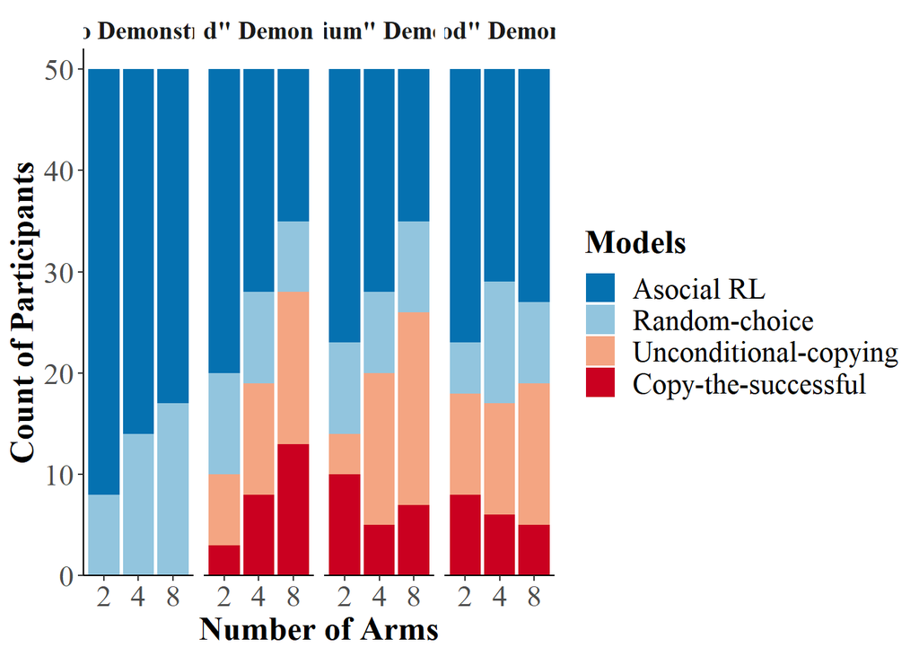

### The Effects of Arms Number and the Demonstrator’s Performance on the Choice of a Social Strategy As Opposed to an Asocial One

```
## Generalized linear mixed model fit by maximum likelihood (Laplace
##   Approximation) [glmerMod]
##  Family: binomial  ( logit )
## Formula: social ~ num_arms + demo + (1 | id)
##    Data: filter(df1, demo != "No")
## Control: glmerControl(optimizer = "bobyqa")
##
##      AIC      BIC   logLik deviance df.resid
##    518.6    543.3   -253.3    506.6      444
##
## Scaled residuals:
##     Min      1Q  Median      3Q     Max
## -2.0747 -0.5774 -0.3003  0.5995  3.5495
##
## Random effects:
##  Groups Name        Variance Std.Dev.
##  id     (Intercept) 2.513    1.585
## Number of obs: 450, groups:  id, 50
##
## Fixed effects:
##             Estimate Std. Error z value Pr(>|z|)
## (Intercept)  -1.3474     0.3583  -3.760  0.00017 ***
## num_arms4     0.6147     0.2934   2.095  0.03617 *
## num_arms8     1.2913     0.2961   4.360  1.3e-05 ***
## demoMedium    0.1255     0.2835   0.443  0.65800
## demoGood     -0.1278     0.2861  -0.447  0.65503
## ---
## Signif. codes:  0 '***' 0.001 '**' 0.01 '*' 0.05 '.' 0.1 ' ' 1
##
## Correlation of Fixed Effects:
##            (Intr) nm_rm4 nm_rm8 demMdm
## num_arms4  -0.451
## num_arms8  -0.470  0.549
## demoMedium -0.405  0.005  0.011
## demoGood   -0.388 -0.005 -0.011  0.499
```

And the results can be illustrated as the figure below:

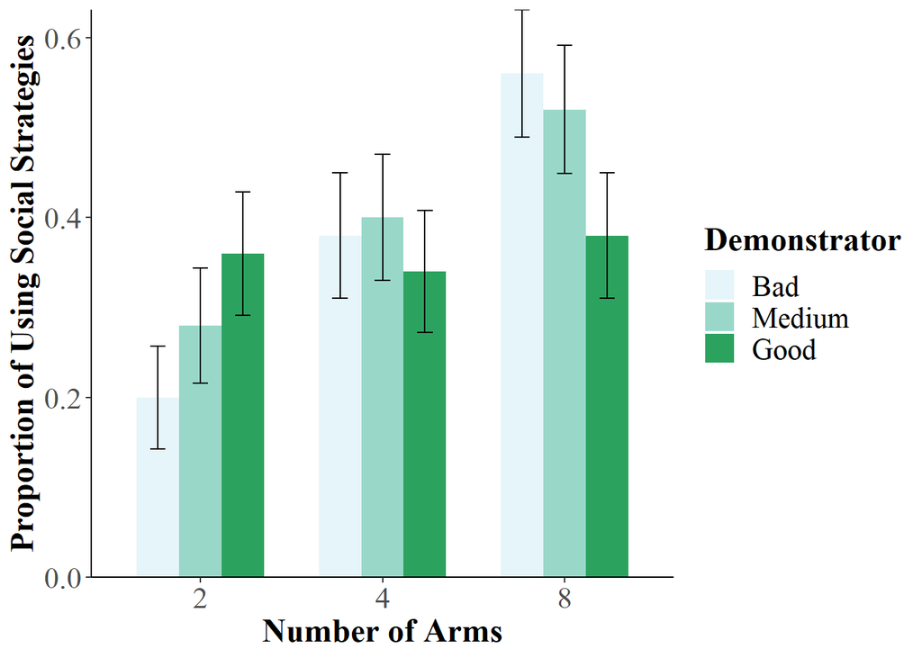

## Study 2

### Number of Participants Using Each Model

| conditions | Asocial RL | Random-choice | Unconditional-copying | Copy-the-successful |
| --- | --- | --- | --- | --- |
| 2no | 41 | 9 | NA | NA |
| 4no | 39 | 11 | NA | NA |
| 8no | 35 | 15 | NA | NA |
| 2low | 28 | 14 | 6 | 2 |
| 4low | 21 | 14 | 9 | 6 |
| 8low | 26 | 8 | 8 | 8 |
| 2mid | 27 | 12 | 5 | 6 |
| 4mid | 24 | 4 | 16 | 6 |
| 8mid | 15 | 5 | 18 | 12 |
| 2high | 27 | 5 | 14 | 4 |
| 4high | 22 | 5 | 19 | 4 |
| 8high | 15 | 8 | 23 | 4 |

### Number of Participants Using a Social or an Asocial Strategy

| conditions | asocial | social |
| --- | --- | --- |
| 2no | 50 | NA |
| 4no | 50 | NA |
| 8no | 50 | NA |
| 2low | 42 | 8 |
| 4low | 35 | 15 |
| 8low | 34 | 16 |
| 2mid | 39 | 11 |
| 4mid | 28 | 22 |
| 8mid | 20 | 30 |
| 2high | 32 | 18 |
| 4high | 27 | 23 |
| 8high | 23 | 27 |

There are 7 participants always using an asocial strategy, and 2 participants always using a social one.

### Figure - Number of Participants Using Each Model

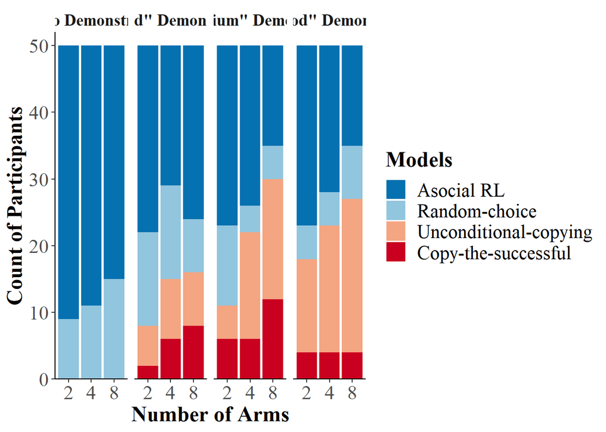

### The Effects of Arms Number and the Demonstrator’s Performance on the Choice of a Social Strategy As Opposed to an Asocial One

```
## Generalized linear mixed model fit by maximum likelihood (Laplace
##   Approximation) [glmerMod]
##  Family: binomial  ( logit )
## Formula: social ~ num_arms + demo + (1 | id)
##    Data: filter(df2, demo != "No")
## Control: glmerControl(optimizer = "bobyqa")
##
##      AIC      BIC   logLik deviance df.resid
##    513.1    537.8   -250.6    501.1      444
##
## Scaled residuals:
##     Min      1Q  Median      3Q     Max
## -2.5597 -0.6075 -0.3019  0.6542  5.5443
##
## Random effects:
##  Groups Name        Variance Std.Dev.
##  id     (Intercept) 2.176    1.475
## Number of obs: 450, groups:  id, 50
##
## Fixed effects:
##             Estimate Std. Error z value Pr(>|z|)
## (Intercept)  -2.3520     0.3816  -6.163 7.14e-10 ***
## num_arms4     1.0049     0.3002   3.347 0.000816 ***
## num_arms8     1.5146     0.3048   4.969 6.74e-07 ***
## demoMedium    1.0375     0.2991   3.469 0.000522 ***
## demoGood      1.2359     0.3006   4.111 3.94e-05 ***
## ---
## Signif. codes:  0 '***' 0.001 '**' 0.01 '*' 0.05 '.' 0.1 ' ' 1
##
## Correlation of Fixed Effects:
##            (Intr) nm_rm4 nm_rm8 demMdm
## num_arms4  -0.498
## num_arms8  -0.532  0.577
## demoMedium -0.498  0.066  0.100
## demoGood   -0.512  0.079  0.119  0.570
```

And the results can be illustrated as the figure below:

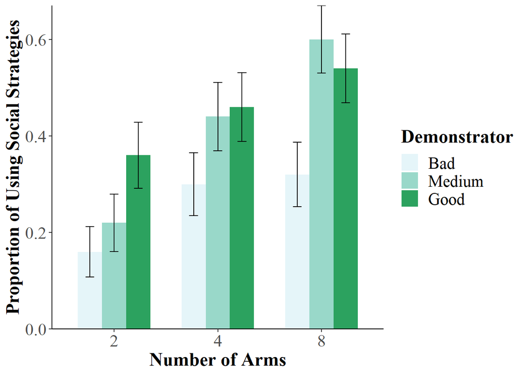

# Parameter Analysis

## Descriptive Statistics

alpha:

| show | num_arms | m_alpha | sd_alpha |
| --- | --- | --- | --- |
| Hide | 2 | 0.56 | 0.36 |
| Hide | 4 | 0.50 | 0.38 |
| Hide | 8 | 0.52 | 0.34 |
| Show | 2 | 0.61 | 0.33 |
| Show | 4 | 0.61 | 0.35 |
| Show | 8 | 0.57 | 0.38 |

beta:

| show | num_arms | m_beta | sd_beta |
| --- | --- | --- | --- |
| Hide | 2 | 0.35 | 0.97 |
| Hide | 4 | 1.34 | 2.82 |
| Hide | 8 | 1.46 | 2.68 |
| Show | 2 | 0.50 | 1.34 |
| Show | 4 | 0.59 | 1.52 |
| Show | 8 | 1.86 | 2.99 |

eta:

| show | demo | num_arms | m_eta | sd_eta |
| --- | --- | --- | --- | --- |
| Hide | Bad | 2 | 0.15 | 0.23 |
| Hide | Bad | 4 | 0.21 | 0.28 |
| Hide | Bad | 8 | 0.24 | 0.29 |
| Hide | Medium | 2 | 0.20 | 0.23 |
| Hide | Medium | 4 | 0.29 | 0.33 |
| Hide | Medium | 8 | 0.27 | 0.31 |
| Hide | Good | 2 | 0.29 | 0.28 |
| Hide | Good | 4 | 0.26 | 0.33 |
| Hide | Good | 8 | 0.31 | 0.35 |
| Show | Bad | 2 | 0.16 | 0.22 |
| Show | Bad | 4 | 0.19 | 0.29 |
| Show | Bad | 8 | 0.18 | 0.30 |
| Show | Medium | 2 | 0.21 | 0.26 |
| Show | Medium | 4 | 0.31 | 0.34 |
| Show | Medium | 8 | 0.29 | 0.32 |
| Show | Good | 2 | 0.27 | 0.29 |
| Show | Good | 4 | 0.39 | 0.40 |
| Show | Good | 8 | 0.42 | 0.36 |

## Study 1

### The Effects of Arms Number and the Demonstrator’s Performance on the Parameters

alpha:

```
## Data: paras1_alpha
## Models:
## m1_alpha.null: alpha ~ 1 + (1 | id)
## m1_alpha: alpha ~ num_arms + (1 | id)
##               Df    AIC    BIC  logLik deviance Chisq Chi Df Pr(>Chisq)
## m1_alpha.null  3 123.40 132.43 -58.700   117.40
## m1_alpha       5 126.52 141.58 -58.261   116.52 0.877      2      0.645
```

```
## Linear mixed model fit by maximum likelihood . t-tests use Satterthwaite's
##   method [lmerModLmerTest]
## Formula: alpha ~ num_arms + (1 | id)
##    Data: paras1_alpha
##
##      AIC      BIC   logLik deviance df.resid
##    126.5    141.6    -58.3    116.5      145
##
## Scaled residuals:
##     Min      1Q  Median      3Q     Max
## -1.5402 -0.8049 -0.1236  0.9265  1.5850
##
## Random effects:
##  Groups   Name        Variance Std.Dev.
##  id       (Intercept) 0.01026  0.1013
##  Residual             0.11784  0.3433
## Number of obs: 150, groups:  id, 50
##
## Fixed effects:
##              Estimate Std. Error        df t value Pr(>|t|)
## (Intercept)   0.55933    0.05062 148.09904  11.050   <2e-16 ***
## num_arms4    -0.06380    0.06866  99.99965  -0.929    0.355
## num_arms8    -0.03972    0.06866  99.99965  -0.578    0.564
## ---
## Signif. codes:  0 '***' 0.001 '**' 0.01 '*' 0.05 '.' 0.1 ' ' 1
##
## Correlation of Fixed Effects:
##           (Intr) nm_rm4
## num_arms4 -0.678
## num_arms8 -0.678  0.500
```

beta:

```
## Data: paras1_beta
## Models:
## m1_beta.null: log(beta) ~ 1 + (1 | id)
## m1_beta: log(beta) ~ num_arms + (1 | id)
##              Df    AIC    BIC  logLik deviance  Chisq Chi Df Pr(>Chisq)
## m1_beta.null  3 636.17 645.20 -315.08   630.17
## m1_beta       5 628.62 643.68 -309.31   618.62 11.544      2   0.003113 **
## ---
## Signif. codes:  0 '***' 0.001 '**' 0.01 '*' 0.05 '.' 0.1 ' ' 1
```

```
## Linear mixed model fit by maximum likelihood . t-tests use Satterthwaite's
##   method [lmerModLmerTest]
## Formula: log(beta) ~ num_arms + (1 | id)
##    Data: paras1_beta
##
##      AIC      BIC   logLik deviance df.resid
##    628.6    643.7   -309.3    618.6      145
##
## Scaled residuals:
##      Min       1Q   Median       3Q      Max
## -2.05053 -0.55670 -0.06867  0.58511  2.65313
##
## Random effects:
##  Groups   Name        Variance Std.Dev.
##  id       (Intercept) 2.229    1.493
##  Residual             2.297    1.516
## Number of obs: 150, groups:  id, 50
##
## Fixed effects:
##             Estimate Std. Error       df t value Pr(>|t|)
## (Intercept)  -2.6494     0.3009 101.0082  -8.806  3.8e-14 ***
## num_arms4     0.5013     0.3031 100.0000   1.654 0.101338
## num_arms8     1.0599     0.3031 100.0000   3.496 0.000705 ***
## ---
## Signif. codes:  0 '***' 0.001 '**' 0.01 '*' 0.05 '.' 0.1 ' ' 1
##
## Correlation of Fixed Effects:
##           (Intr) nm_rm4
## num_arms4 -0.504
## num_arms8 -0.504  0.500
```

eta:

```
## Data: paras1_eta
## Models:
## m1_eta.null: eta ~ 1 + (1 | id)
## m1_eta: eta ~ num_arms + (1 | id)
## m1_eta.0: eta ~ num_arms + demo + (1 | id)
## m1_eta.1: eta ~ num_arms * demo + (1 | id)
##             Df     AIC    BIC  logLik deviance   Chisq Chi Df Pr(>Chisq)
## m1_eta.null  3  3.1696 15.497  1.4152  -2.8304
## m1_eta       5  0.8949 21.441  4.5525  -9.1051  6.2747      2    0.04340 *
## m1_eta.0     7 -8.5723 20.192 11.2861 -22.5723 13.4672      2    0.00119 **
## m1_eta.1    11 -5.8511 39.351 13.9256 -27.8511  5.2788      4    0.25986
## ---
## Signif. codes:  0 '***' 0.001 '**' 0.01 '*' 0.05 '.' 0.1 ' ' 1
```

```
## Linear mixed model fit by maximum likelihood . t-tests use Satterthwaite's
##   method [lmerModLmerTest]
## Formula: eta ~ num_arms + demo + (1 | id)
##    Data: paras1_eta
##
##      AIC      BIC   logLik deviance df.resid
##     -8.6     20.2     11.3    -22.6      443
##
## Scaled residuals:
##     Min      1Q  Median      3Q     Max
## -2.4842 -0.6144 -0.1285  0.4931  3.7286
##
## Random effects:
##  Groups   Name        Variance Std.Dev.
##  id       (Intercept) 0.04232  0.2057
##  Residual             0.04320  0.2079
## Number of obs: 450, groups:  id, 50
##
## Fixed effects:
##              Estimate Std. Error        df t value Pr(>|t|)
## (Intercept)   0.16348    0.03642  97.04287   4.489 1.97e-05 ***
## num_arms4     0.03863    0.02400 400.00000   1.610 0.108290
## num_arms8     0.06063    0.02400 400.00000   2.526 0.011922 *
## demoMedium    0.05544    0.02400 400.00000   2.310 0.021412 *
## demoGood      0.08782    0.02400 400.00000   3.659 0.000287 ***
## ---
## Signif. codes:  0 '***' 0.001 '**' 0.01 '*' 0.05 '.' 0.1 ' ' 1
##
## Correlation of Fixed Effects:
##            (Intr) nm_rm4 nm_rm8 demMdm
## num_arms4  -0.330
## num_arms8  -0.330  0.500
## demoMedium -0.330  0.000  0.000
## demoGood   -0.330  0.000  0.000  0.500
```

## Study 2

### The Effects of Arms Number and the Demonstrator’s Performance on the Parameters

alpha:

```
## Data: paras2_alpha
## Models:
## m2_alpha.null: alpha ~ 1 + (1 | id)
## m2_alpha: alpha ~ num_arms + (1 | id)
##               Df    AIC    BIC  logLik deviance  Chisq Chi Df Pr(>Chisq)
## m2_alpha.null  3 103.24 112.27 -48.621   97.241
## m2_alpha       5 106.68 121.74 -48.342   96.683 0.5577      2     0.7566
```

```
## Linear mixed model fit by maximum likelihood . t-tests use Satterthwaite's
##   method [lmerModLmerTest]
## Formula: alpha ~ num_arms + (1 | id)
##    Data: paras2_alpha
##
##      AIC      BIC   logLik deviance df.resid
##    106.7    121.7    -48.3     96.7      145
##
## Scaled residuals:
##      Min       1Q   Median       3Q      Max
## -2.24697 -0.70607  0.03245  0.77142  1.44282
##
## Random effects:
##  Groups   Name        Variance Std.Dev.
##  id       (Intercept) 0.04126  0.2031
##  Residual             0.08210  0.2865
## Number of obs: 150, groups:  id, 50
##
## Fixed effects:
##               Estimate Std. Error         df t value Pr(>|t|)
## (Intercept)   0.613184   0.049672 122.575973  12.345   <2e-16 ***
## num_arms4    -0.007103   0.057308 100.000000  -0.124    0.902
## num_arms8    -0.040154   0.057308 100.000000  -0.701    0.485
## ---
## Signif. codes:  0 '***' 0.001 '**' 0.01 '*' 0.05 '.' 0.1 ' ' 1
##
## Correlation of Fixed Effects:
##           (Intr) nm_rm4
## num_arms4 -0.577
## num_arms8 -0.577  0.500
```

beta:

```
## Data: paras2_beta
## Models:
## m2_beta.null: log(beta) ~ 1 + (1 | id)
## m2_beta: log(beta) ~ num_arms + (1 | id)
##              Df    AIC    BIC  logLik deviance  Chisq Chi Df Pr(>Chisq)
## m2_beta.null  3 628.61 637.64 -311.30   622.61
## m2_beta       5 626.09 641.14 -308.05   616.09 6.5178      2    0.03843 *
## ---
## Signif. codes:  0 '***' 0.001 '**' 0.01 '*' 0.05 '.' 0.1 ' ' 1
```

```
## Linear mixed model fit by maximum likelihood . t-tests use Satterthwaite's
##   method [lmerModLmerTest]
## Formula: log(beta) ~ num_arms + (1 | id)
##    Data: paras2_beta
##
##      AIC      BIC   logLik deviance df.resid
##    626.1    641.1   -308.0    616.1      145
##
## Scaled residuals:
##      Min       1Q   Median       3Q      Max
## -2.18039 -0.71138  0.05822  0.61151  2.14344
##
## Random effects:
##  Groups   Name        Variance Std.Dev.
##  id       (Intercept) 1.500    1.225
##  Residual             2.532    1.591
## Number of obs: 150, groups:  id, 50
##
## Fixed effects:
##              Estimate Std. Error        df t value Pr(>|t|)
## (Intercept)  -2.29354    0.28396 117.48135  -8.077 6.54e-13 ***
## num_arms4     0.03331    0.31823 100.00000   0.105   0.9168
## num_arms8     0.73129    0.31823 100.00000   2.298   0.0236 *
## ---
## Signif. codes:  0 '***' 0.001 '**' 0.01 '*' 0.05 '.' 0.1 ' ' 1
##
## Correlation of Fixed Effects:
##           (Intr) nm_rm4
## num_arms4 -0.560
## num_arms8 -0.560  0.500
```

eta:

```
## Data: paras2_eta
## Models:
## m2_eta.null: eta ~ 1 + (1 | id)
## m2_eta: eta ~ num_arms + (1 | id)
## m2_eta.0: eta ~ num_arms + demo + (1 | id)
## m2_eta.1: eta ~ num_arms * demo + (1 | id)
##             Df     AIC    BIC  logLik deviance   Chisq Chi Df Pr(>Chisq)
## m2_eta.null  3 139.553 151.88 -66.777  133.553
## m2_eta       5 132.422 152.97 -61.211  122.422 11.1307      2   0.003828 **
## m2_eta.0     7  96.685 125.45 -41.342   82.685 39.7376      2   2.35e-09 ***
## m2_eta.1    11 100.450 145.65 -39.225   78.450  4.2345      4   0.375193
## ---
## Signif. codes:  0 '***' 0.001 '**' 0.01 '*' 0.05 '.' 0.1 ' ' 1
```

```
## Linear mixed model fit by maximum likelihood . t-tests use Satterthwaite's
##   method [lmerModLmerTest]
## Formula: eta ~ num_arms + demo + (1 | id)
##    Data: paras2_eta
##
##      AIC      BIC   logLik deviance df.resid
##     96.7    125.4    -41.3     82.7      443
##
## Scaled residuals:
##     Min      1Q  Median      3Q     Max
## -3.0817 -0.6144 -0.1334  0.4404  3.3454
##
## Random effects:
##  Groups   Name        Variance Std.Dev.
##  id       (Intercept) 0.04077  0.2019
##  Residual             0.05623  0.2371
## Number of obs: 450, groups:  id, 50
##
## Fixed effects:
##              Estimate Std. Error        df t value Pr(>|t|)
## (Intercept)   0.12495    0.03795 113.27507   3.292 0.001325 **
## num_arms4     0.08450    0.02738 400.00000   3.086 0.002167 **
## num_arms8     0.08291    0.02738 400.00000   3.028 0.002620 **
## demoMedium    0.09210    0.02738 400.00000   3.364 0.000843 ***
## demoGood      0.17692    0.02738 400.00000   6.462 3.01e-10 ***
## ---
## Signif. codes:  0 '***' 0.001 '**' 0.01 '*' 0.05 '.' 0.1 ' ' 1
##
## Correlation of Fixed Effects:
##            (Intr) nm_rm4 nm_rm8 demMdm
## num_arms4  -0.361
## num_arms8  -0.361  0.500
## demoMedium -0.361  0.000  0.000
## demoGood   -0.361  0.000  0.000  0.500
```

## Taken Together

### The Effect of the Presence of the Demonstrator’s Performance Level on the Parameters

alpha:

```
## Data: paras_alpha
## Models:
## m_alpha.null: alpha ~ 1 + (1 | id)
## m_alpha: alpha ~ num_arms + (1 | id)
## m_alpha.0: alpha ~ num_arms + show + (1 | id)
## m_alpha.1: alpha ~ num_arms * show + (1 | id)
##              Df    AIC    BIC  logLik deviance  Chisq Chi Df Pr(>Chisq)
## m_alpha.null  3 227.47 238.58 -110.74   221.47
## m_alpha       5 230.52 249.04 -110.26   220.52 0.9527      2     0.6210
## m_alpha.0     6 230.31 252.54 -109.16   218.31 2.2058      1     0.1375
## m_alpha.1     8 233.77 263.40 -108.89   217.77 0.5394      2     0.7636
```

```
## Linear mixed model fit by maximum likelihood . t-tests use Satterthwaite's
##   method [lmerModLmerTest]
## Formula: alpha ~ num_arms * show + (1 | id)
##    Data: paras_alpha
##
##      AIC      BIC   logLik deviance df.resid
##    233.8    263.4   -108.9    217.8      292
##
## Scaled residuals:
##      Min       1Q   Median       3Q      Max
## -2.00830 -0.75737 -0.09986  0.85926  1.85918
##
## Random effects:
##  Groups   Name        Variance Std.Dev.
##  id       (Intercept) 0.02576  0.1605
##  Residual             0.09997  0.3162
## Number of obs: 300, groups:  id, 100
##
## Fixed effects:
##                      Estimate Std. Error         df t value Pr(>|t|)
## (Intercept)         5.593e-01  5.015e-02  2.768e+02  11.154   <2e-16 ***
## num_arms4          -6.380e-02  6.324e-02  2.000e+02  -1.009    0.314
## num_arms8          -3.972e-02  6.324e-02  2.000e+02  -0.628    0.531
## showShow            5.385e-02  7.092e-02  2.768e+02   0.759    0.448
## num_arms4:showShow  5.670e-02  8.943e-02  2.000e+02   0.634    0.527
## num_arms8:showShow -4.375e-04  8.943e-02  2.000e+02  -0.005    0.996
## ---
## Signif. codes:  0 '***' 0.001 '**' 0.01 '*' 0.05 '.' 0.1 ' ' 1
##
## Correlation of Fixed Effects:
##             (Intr) nm_rm4 nm_rm8 shwShw nm_4:S
## num_arms4   -0.631
## num_arms8   -0.631  0.500
## showShow    -0.707  0.446  0.446
## nm_rms4:shS  0.446 -0.707 -0.354 -0.631
## nm_rms8:shS  0.446 -0.354 -0.707 -0.631  0.500
```

beta:

```
## Data: paras_beta
## Models:
## m_beta.null: log(beta) ~ 1 + (1 | id)
## m_beta: log(beta) ~ num_arms + (1 | id)
## m_beta.0: log(beta) ~ num_arms + show + (1 | id)
## m_beta.1: log(beta) ~ num_arms * show + (1 | id)
##             Df    AIC    BIC  logLik deviance   Chisq Chi Df Pr(>Chisq)
## m_beta.null  3 1259.7 1270.8 -626.83   1253.7
## m_beta       5 1247.0 1265.5 -618.48   1237.0 16.6893      2  0.0002377 ***
## m_beta.0     6 1248.9 1271.1 -618.45   1236.9  0.0765      1  0.7821497
## m_beta.1     8 1251.7 1281.3 -617.85   1235.7  1.1919      2  0.5510280
## ---
## Signif. codes:  0 '***' 0.001 '**' 0.01 '*' 0.05 '.' 0.1 ' ' 1
```

```
## Linear mixed model fit by maximum likelihood . t-tests use Satterthwaite's
##   method [lmerModLmerTest]
## Formula: log(beta) ~ num_arms + (1 | id)
##    Data: paras_beta
##
##      AIC      BIC   logLik deviance df.resid
##   1247.0   1265.5   -618.5   1237.0      295
##
## Scaled residuals:
##      Min       1Q   Median       3Q      Max
## -2.34684 -0.64928  0.01208  0.59197  2.58638
##
## Random effects:
##  Groups   Name        Variance Std.Dev.
##  id       (Intercept) 1.862    1.364
##  Residual             2.429    1.558
## Number of obs: 300, groups:  id, 100
##
## Fixed effects:
##             Estimate Std. Error       df t value Pr(>|t|)
## (Intercept)  -2.4715     0.2071 217.9409 -11.932  < 2e-16 ***
## num_arms4     0.2673     0.2204 200.0000   1.213    0.227
## num_arms8     0.8956     0.2204 200.0000   4.063 6.95e-05 ***
## ---
## Signif. codes:  0 '***' 0.001 '**' 0.01 '*' 0.05 '.' 0.1 ' ' 1
##
## Correlation of Fixed Effects:
##           (Intr) nm_rm4
## num_arms4 -0.532
## num_arms8 -0.532  0.500
```

eta:

```
## Data: paras_eta
## Models:
## m_eta.null: eta ~ 1 + (1 | id)
## m_eta: eta ~ num_arms + (1 | id)
## m_eta.0: eta ~ num_arms + demo + (1 | id)
## m_eta.1: eta ~ num_arms + demo + show + (1 | id)
## m_eta.2: eta ~ num_arms + demo * show + (1 | id)
## m_eta.3: eta ~ num_arms * demo * show + (1 | id)
##            Df     AIC    BIC  logLik deviance   Chisq Chi Df Pr(>Chisq)
## m_eta.null  3 148.672 163.08 -71.336  142.672
## m_eta       5 135.937 159.95 -62.969  125.937 16.7346      2  0.0002323 ***
## m_eta.0     7  88.995 122.61 -37.498   74.995 50.9420      2  8.671e-12 ***
## m_eta.1     8  90.634 129.05 -37.317   74.634  0.3614      1  0.5477217
## m_eta.2    10  88.618 136.64 -34.309   68.618  6.0164      2  0.0493807 *
## m_eta.3    20  97.655 193.70 -28.828   57.655 10.9622     10  0.3604719
## ---
## Signif. codes:  0 '***' 0.001 '**' 0.01 '*' 0.05 '.' 0.1 ' ' 1
```

```
## Linear mixed model fit by maximum likelihood . t-tests use Satterthwaite's
##   method [lmerModLmerTest]
## Formula: eta ~ num_arms + demo * show + (1 | id)
##    Data: paras_eta
##
##      AIC      BIC   logLik deviance df.resid
##     88.6    136.6    -34.3     68.6      890
##
## Scaled residuals:
##     Min      1Q  Median      3Q     Max
## -3.2560 -0.6145 -0.1428  0.4659  3.5041
##
## Random effects:
##  Groups   Name        Variance Std.Dev.
##  id       (Intercept) 0.04153  0.2038
##  Residual             0.04981  0.2232
## Number of obs: 900, groups:  id, 100
##
## Fixed effects:
##                      Estimate Std. Error        df t value Pr(>|t|)
## (Intercept)           0.15212    0.03569 180.19979   4.263 3.25e-05 ***
## num_arms4             0.06157    0.01822 800.00001   3.379 0.000764 ***
## num_arms8             0.07177    0.01822 800.00001   3.938 8.92e-05 ***
## demoMedium            0.05544    0.02577 800.00001   2.151 0.031771 *
## demoGood              0.08782    0.02577 800.00001   3.408 0.000688 ***
## showShow             -0.01581    0.04822 151.52204  -0.328 0.743442
## demoMedium:showShow   0.03666    0.03645 800.00001   1.006 0.314782
## demoGood:showShow     0.08910    0.03645 800.00001   2.445 0.014712 *
## ---
## Signif. codes:  0 '***' 0.001 '**' 0.01 '*' 0.05 '.' 0.1 ' ' 1
##
## Correlation of Fixed Effects:
##             (Intr) nm_rm4 nm_rm8 demMdm demoGd shwShw dmMd:S
## num_arms4   -0.255
## num_arms8   -0.255  0.500
## demoMedium  -0.361  0.000  0.000
## demoGood    -0.361  0.000  0.000  0.500
## showShow    -0.676  0.000  0.000  0.267  0.267
## dmMdm:shwSh  0.255  0.000  0.000 -0.707 -0.354 -0.378
## dmGd:shwShw  0.255  0.000  0.000 -0.354 -0.707 -0.378  0.500
```

### Figure - The Effect of the Presence of the Demonstrator’s Performance Level on eta

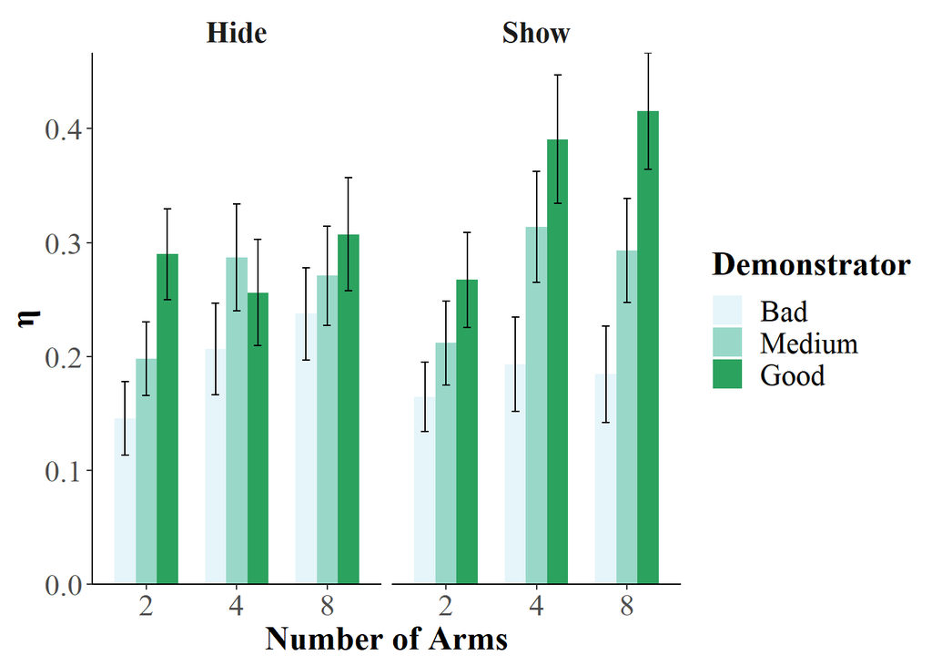

# Individual Differences

## Study 1

### The Effects of Demographic Features on the Parameters

alpha:

```
## Data: paras_alpha %>% filter(show == "Hide")
## Models:
## m1_idv_alpha.null: alpha ~ 1 + (1 | id)
## m1_idv_alpha: alpha ~ age + edu + gender + (1 | id)
##                   Df    AIC    BIC  logLik deviance  Chisq Chi Df Pr(>Chisq)
## m1_idv_alpha.null  3 123.40 132.43 -58.700   117.40
## m1_idv_alpha       7 127.61 148.69 -56.806   113.61 3.7877      4     0.4355
```

```
## Linear mixed model fit by maximum likelihood . t-tests use Satterthwaite's
##   method [lmerModLmerTest]
## Formula: alpha ~ age + edu + gender + (1 | id)
##    Data: paras_alpha %>% filter(show == "Hide")
##
##      AIC      BIC   logLik deviance df.resid
##    127.6    148.7    -56.8    113.6      143
##
## Scaled residuals:
##     Min      1Q  Median      3Q     Max
## -1.7949 -0.8444 -0.1436  0.9918  1.5801
##
## Random effects:
##  Groups   Name        Variance Std.Dev.
##  id       (Intercept) 0.006302 0.07939
##  Residual             0.118877 0.34479
## Number of obs: 150, groups:  id, 50
##
## Fixed effects:
##                 Estimate Std. Error        df t value Pr(>|t|)
## (Intercept)     0.704810   0.223159 49.999985   3.158  0.00269 **
## age             0.001685   0.003324 49.999985   0.507  0.61445
## edu            -0.011449   0.009522 49.999985  -1.202  0.23486
## gendermale     -0.110052   0.074061 49.999985  -1.486  0.14357
## gendernottosay -0.036860   0.222810 49.999985  -0.165  0.86927
## ---
## Signif. codes:  0 '***' 0.001 '**' 0.01 '*' 0.05 '.' 0.1 ' ' 1
##
## Correlation of Fixed Effects:
##             (Intr) age    edu    gndrml
## age         -0.709
## edu         -0.802  0.223
## gendermale  -0.613  0.306  0.379
## gendernttsy -0.173  0.084  0.095  0.236
```

beta:

```
## Data: paras_beta %>% filter(show == "Hide")
## Models:
## m1_idv_beta.null: beta ~ 1 + (1 | id)
## m1_idv_beta: beta ~ age + edu + gender + (1 | id)
##                  Df    AIC    BIC  logLik deviance  Chisq Chi Df Pr(>Chisq)
## m1_idv_beta.null  3 673.61 682.64 -333.80   667.61
## m1_idv_beta       7 679.27 700.34 -332.63   665.27 2.3369      4     0.6741
```

```
## Linear mixed model fit by maximum likelihood . t-tests use Satterthwaite's
##   method [lmerModLmerTest]
## Formula: beta ~ age + edu + gender + (1 | id)
##    Data: paras_beta %>% filter(show == "Hide")
##
##      AIC      BIC   logLik deviance df.resid
##    679.3    700.3   -332.6    665.3      143
##
## Scaled residuals:
##     Min      1Q  Median      3Q     Max
## -1.8477 -0.2937 -0.2181 -0.0893  4.0317
##
## Random effects:
##  Groups   Name        Variance Std.Dev.
##  id       (Intercept) 1.611    1.269
##  Residual             3.748    1.936
## Number of obs: 150, groups:  id, 50
##
## Fixed effects:
##                Estimate Std. Error       df t value Pr(>|t|)
## (Intercept)     2.74802    1.76094 50.00000   1.561    0.125
## age            -0.01411    0.02623 50.00000  -0.538    0.593
## edu            -0.09005    0.07513 50.00000  -1.199    0.236
## gendermale      0.10195    0.58441 50.00000   0.174    0.862
## gendernottosay -0.86081    1.75819 50.00000  -0.490    0.627
##
## Correlation of Fixed Effects:
##             (Intr) age    edu    gndrml
## age         -0.709
## edu         -0.802  0.223
## gendermale  -0.613  0.306  0.379
## gendernttsy -0.173  0.084  0.095  0.236
```

eta:

```
## Data: paras_eta %>% filter(show == "Hide")
## Models:
## m1_idv_eta.null: eta ~ 1 + (1 | id)
## m1_idv_eta: eta ~ edu + age + gender + (1 | id)
##                 Df    AIC    BIC logLik deviance  Chisq Chi Df Pr(>Chisq)
## m1_idv_eta.null  3 3.1696 15.497 1.4152  -2.8304
## m1_idv_eta       7 4.4681 33.233 4.7660  -9.5319 6.7016      4     0.1525
```

```
## Linear mixed model fit by maximum likelihood . t-tests use Satterthwaite's
##   method [lmerModLmerTest]
## Formula: eta ~ edu + age + gender + (1 | id)
##    Data: paras_eta %>% filter(show == "Hide")
##
##      AIC      BIC   logLik deviance df.resid
##      4.5     33.2      4.8     -9.5      443
##
## Scaled residuals:
##     Min      1Q  Median      3Q     Max
## -2.2533 -0.5927 -0.1478  0.4969  3.4936
##
## Random effects:
##  Groups   Name        Variance Std.Dev.
##  id       (Intercept) 0.03616  0.1902
##  Residual             0.04539  0.2131
## Number of obs: 450, groups:  id, 50
##
## Fixed effects:
##                 Estimate Std. Error        df t value Pr(>|t|)
## (Intercept)     0.702303   0.211379 49.999996   3.322  0.00167 **
## edu            -0.013047   0.009019 49.999996  -1.447  0.15426
## age            -0.004614   0.003149 49.999995  -1.466  0.14904
## gendermale     -0.164446   0.070152 49.999995  -2.344  0.02309 *
## gendernottosay -0.302691   0.211049 49.999995  -1.434  0.15773
## ---
## Signif. codes:  0 '***' 0.001 '**' 0.01 '*' 0.05 '.' 0.1 ' ' 1
##
## Correlation of Fixed Effects:
##             (Intr) edu    age    gndrml
## edu         -0.802
## age         -0.709  0.223
## gendermale  -0.613  0.379  0.306
## gendernttsy -0.173  0.095  0.084  0.236
```

### The Effect of Asocial Exploration Tendency on Copying Rate

```
## Data: paras_all %>% filter(show == "Hide")
## Models:
## m1_beta: eta ~ num_arms + demo + (1 | id)
## m1_beta.0: eta ~ num_arms + demo + beta + (1 | id)
## m1_beta.1: eta ~ (num_arms + demo) * beta + (1 | id)
##           Df      AIC    BIC logLik deviance  Chisq Chi Df Pr(>Chisq)
## m1_beta    7  -8.5723 20.192 11.286  -22.572
## m1_beta.0  8 -10.6588 22.215 13.329  -26.659 4.0865      1    0.04323 *
## m1_beta.1 12  -8.5006 40.810 16.250  -32.501 5.8418      4    0.21127
## ---
## Signif. codes:  0 '***' 0.001 '**' 0.01 '*' 0.05 '.' 0.1 ' ' 1
```

```
## Linear mixed model fit by maximum likelihood . t-tests use Satterthwaite's
##   method [lmerModLmerTest]
## Formula: eta ~ num_arms + demo + beta + (1 | id)
##    Data: paras_all %>% filter(show == "Hide")
##
##      AIC      BIC   logLik deviance df.resid
##    -10.7     22.2     13.3    -26.7      442
##
## Scaled residuals:
##     Min      1Q  Median      3Q     Max
## -2.2790 -0.6334 -0.1351  0.5065  3.7521
##
## Random effects:
##  Groups   Name        Variance Std.Dev.
##  id       (Intercept) 0.03976  0.1994
##  Residual             0.04307  0.2075
## Number of obs: 450, groups:  id, 50
##
## Fixed effects:
##              Estimate Std. Error        df t value Pr(>|t|)
## (Intercept) 1.591e-01  3.575e-02 9.927e+01   4.449 2.26e-05 ***
## num_arms4   2.632e-02  2.471e-02 4.052e+02   1.065 0.287415
## num_arms8   4.685e-02  2.490e-02 4.066e+02   1.882 0.060585 .
## demoMedium  5.544e-02  2.396e-02 3.993e+02   2.313 0.021207 *
## demoGood    8.782e-02  2.396e-02 3.993e+02   3.665 0.000281 ***
## beta        1.245e-02  6.097e-03 4.491e+02   2.042 0.041757 *
## ---
## Signif. codes:  0 '***' 0.001 '**' 0.01 '*' 0.05 '.' 0.1 ' ' 1
##
## Correlation of Fixed Effects:
##            (Intr) nm_rm4 nm_rm8 demMdm demoGd
## num_arms4  -0.310
## num_arms8  -0.306  0.533
## demoMedium -0.335  0.000  0.000
## demoGood   -0.335  0.000  0.000  0.500
## beta       -0.060 -0.244 -0.271  0.000  0.000
```

## Study 2

### The Effects of Demographic Features on the Parameters

alpha:

```
## Data: paras_alpha %>% filter(show == "Show")
## Models:
## m2_idv_alpha.null: alpha ~ 1 + (1 | id)
## m2_idv_alpha: alpha ~ age + edu + gender + (1 | id)
##                   Df    AIC    BIC  logLik deviance  Chisq Chi Df Pr(>Chisq)
## m2_idv_alpha.null  3 103.24 112.27 -48.621   97.241
## m2_idv_alpha       6 105.66 123.72 -46.828   93.656 3.5848      3     0.3099
```

```
## Linear mixed model fit by maximum likelihood . t-tests use Satterthwaite's
##   method [lmerModLmerTest]
## Formula: alpha ~ age + edu + gender + (1 | id)
##    Data: paras_alpha %>% filter(show == "Show")
##
##      AIC      BIC   logLik deviance df.resid
##    105.7    123.7    -46.8     93.7      144
##
## Scaled residuals:
##     Min      1Q  Median      3Q     Max
## -2.2355 -0.6740 -0.0040  0.7591  1.5682
##
## Random effects:
##  Groups   Name        Variance Std.Dev.
##  id       (Intercept) 0.03636  0.1907
##  Residual             0.08256  0.2873
## Number of obs: 150, groups:  id, 50
##
## Fixed effects:
##              Estimate Std. Error        df t value Pr(>|t|)
## (Intercept)  0.292436   0.241106 49.999999   1.213    0.231
## age          0.004220   0.003434 49.999999   1.229    0.225
## edu          0.011417   0.009771 49.999999   1.168    0.248
## gendermale  -0.047090   0.083343 49.999999  -0.565    0.575
##
## Correlation of Fixed Effects:
##            (Intr) age    edu
## age        -0.753
## edu        -0.712  0.159
## gendermale -0.503  0.349  0.101
```

beta:

```
## Data: paras_beta %>% filter(show == "Show")
## Models:
## m2_idv_beta.null: beta ~ 1 + (1 | id)
## m2_idv_beta: beta ~ age + edu + gender + (1 | id)
##                  Df    AIC    BIC  logLik deviance  Chisq Chi Df Pr(>Chisq)
## m2_idv_beta.null  3 649.42 658.45 -321.71   643.42
## m2_idv_beta       6 648.81 666.87 -318.40   636.81 6.6147      3    0.08525 .
## ---
## Signif. codes:  0 '***' 0.001 '**' 0.01 '*' 0.05 '.' 0.1 ' ' 1
```

```
## Linear mixed model fit by maximum likelihood . t-tests use Satterthwaite's
##   method [lmerModLmerTest]
## Formula: beta ~ age + edu + gender + (1 | id)
##    Data: paras_beta %>% filter(show == "Show")
##
##      AIC      BIC   logLik deviance df.resid
##    648.8    666.9   -318.4    636.8      144
##
## Scaled residuals:
##     Min      1Q  Median      3Q     Max
## -1.8094 -0.3429 -0.2070 -0.0191  3.2114
##
## Random effects:
##  Groups   Name        Variance Std.Dev.
##  id       (Intercept) 1.134    1.065
##  Residual             3.211    1.792
## Number of obs: 150, groups:  id, 50
##
## Fixed effects:
##              Estimate Std. Error        df t value Pr(>|t|)
## (Intercept)  0.980432   1.416414 50.000000   0.692   0.4920
## age          0.008472   0.020174 50.000000   0.420   0.6763
## edu         -0.073676   0.057402 50.000000  -1.284   0.2052
## gendermale   1.068034   0.489610 50.000000   2.181   0.0339 *
## ---
## Signif. codes:  0 '***' 0.001 '**' 0.01 '*' 0.05 '.' 0.1 ' ' 1
##
## Correlation of Fixed Effects:
##            (Intr) age    edu
## age        -0.753
## edu        -0.712  0.159
## gendermale -0.503  0.349  0.101
```

eta:

```
## Data: paras_eta %>% filter(show == "Show")
## Models:
## m2_idv_eta.null: eta ~ 1 + (1 | id)
## m2_idv_eta: eta ~ edu + age + gender + (1 | id)
##                 Df    AIC    BIC  logLik deviance  Chisq Chi Df Pr(>Chisq)
## m2_idv_eta.null  3 139.55 151.88 -66.777   133.55
## m2_idv_eta       6 140.10 164.76 -64.051   128.10 5.4519      3     0.1415
```

```
## Linear mixed model fit by maximum likelihood . t-tests use Satterthwaite's
##   method [lmerModLmerTest]
## Formula: eta ~ edu + age + gender + (1 | id)
##    Data: paras_eta %>% filter(show == "Show")
##
##      AIC      BIC   logLik deviance df.resid
##    140.1    164.8    -64.1    128.1      444
##
## Scaled residuals:
##     Min      1Q  Median      3Q     Max
## -2.7055 -0.5394 -0.2177  0.4432  2.9850
##
## Random effects:
##  Groups   Name        Variance Std.Dev.
##  id       (Intercept) 0.03506  0.1873
##  Residual             0.06385  0.2527
## Number of obs: 450, groups:  id, 50
##
## Fixed effects:
##              Estimate Std. Error        df t value Pr(>|t|)
## (Intercept)  0.104562   0.195869 49.999994   0.534    0.596
## edu          0.012552   0.007938 49.999993   1.581    0.120
## age         -0.001956   0.002790 49.999993  -0.701    0.486
## gendermale   0.085507   0.067706 49.999993   1.263    0.212
##
## Correlation of Fixed Effects:
##            (Intr) edu    age
## edu        -0.712
## age        -0.753  0.159
## gendermale -0.503  0.101  0.349
```

### The Effect of Asocial Exploration Tendency on Copying Rate

```
## Data: paras_all %>% filter(show == "Show")
## Models:
## m2_beta: eta ~ num_arms + demo + (1 | id)
## m2_beta.0: eta ~ num_arms + demo + beta + (1 | id)
## m2_beta.1: eta ~ (num_arms + demo) * beta + (1 | id)
##           Df     AIC    BIC  logLik deviance  Chisq Chi Df Pr(>Chisq)
## m2_beta    7  96.685 125.45 -41.342   82.685
## m2_beta.0  8  97.679 130.55 -40.840   81.679 1.0054      1     0.3160
## m2_beta.1 12 104.570 153.88 -40.285   80.570 1.1095      4     0.8928
```

```
## Linear mixed model fit by maximum likelihood . t-tests use Satterthwaite's
##   method [lmerModLmerTest]
## Formula: eta ~ num_arms + demo + beta + (1 | id)
##    Data: paras_all %>% filter(show == "Show")
##
##      AIC      BIC   logLik deviance df.resid
##     97.7    130.6    -40.8     81.7      442
##
## Scaled residuals:
##     Min      1Q  Median      3Q     Max
## -3.0376 -0.6208 -0.1443  0.4566  3.4068
##
## Random effects:
##  Groups   Name        Variance Std.Dev.
##  id       (Intercept) 0.03991  0.1998
##  Residual             0.05621  0.2371
## Number of obs: 450, groups:  id, 50
##
## Fixed effects:
##              Estimate Std. Error        df t value Pr(>|t|)
## (Intercept) 1.210e-01  3.792e-02 1.156e+02   3.192 0.001818 **
## num_arms4   8.380e-02  2.739e-02 3.998e+02   3.060 0.002362 **
## num_arms8   7.234e-02  2.932e-02 4.155e+02   2.467 0.014017 *
## demoMedium  9.210e-02  2.738e-02 3.997e+02   3.364 0.000842 ***
## demoGood    1.769e-01  2.738e-02 3.997e+02   6.462    3e-10 ***
## beta        7.774e-03  7.720e-03 4.382e+02   1.007 0.314518
## ---
## Signif. codes:  0 '***' 0.001 '**' 0.01 '*' 0.05 '.' 0.1 ' ' 1
##
## Correlation of Fixed Effects:
##            (Intr) nm_rm4 nm_rm8 demMdm demoGd
## num_arms4  -0.358
## num_arms8  -0.301  0.476
## demoMedium -0.361  0.000  0.000
## demoGood   -0.361  0.000  0.000  0.500
## beta       -0.102 -0.025 -0.358  0.000  0.000
```